# Youzu Game Analytics

Venkateswarlu Allacheruvu

April 20, 2018

## **Question-1**

**From the given Dataset, determine and analyze Day 1, Day 3, Day 7, Day 15 and Day 30 Retention. (Refer to Session start tab)**

Day N retention also known as classic retention or Retention by Day, is the percent of new users who come back on a specific day.

Day 1, Day 3, Day 7, Day 15 and Day 30 Retention rates are as follows

```
##    Day Retention_Rate
## 1    1           0.75
## 3    3           0.00
## 7    7           0.00
## 15  15           0.75
## 30  30           0.00
```

**Visualization of the classic retention rate or N Day retention rate**

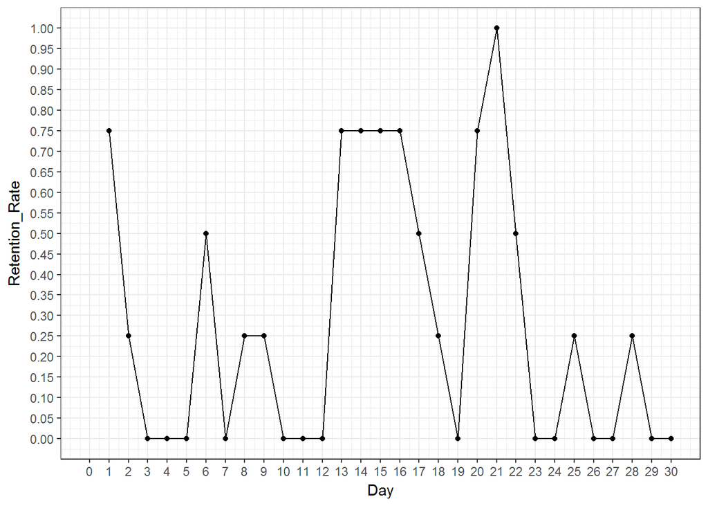

## **Question-2**

**Create a Funnel of level progression and determine if any areas of the game are acting as blockers. (Refer to Level Start tab). Also, identify how many times levels are replayed.**

**Level pregression funnel**

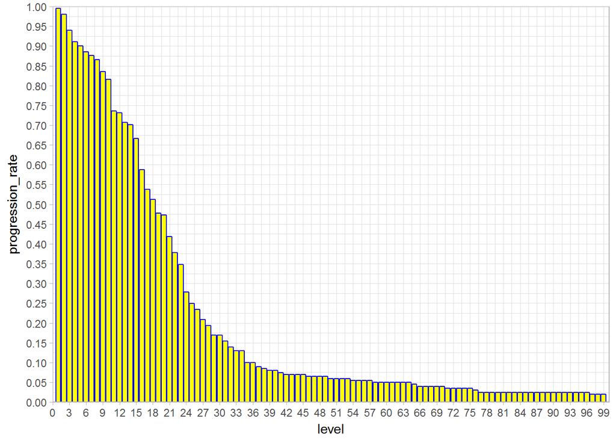

From the chart progression funnel, it is clearly observed that the levels 10, 16, 23 are seeming like level blockers.

**Total number of times level played including all the players**

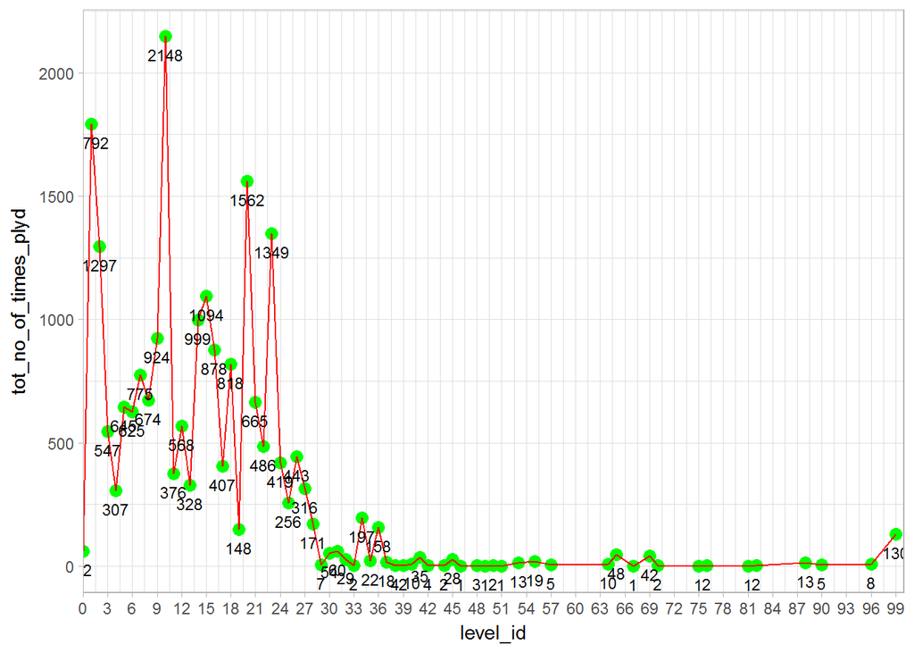

**Levelwise maximum number of sessions played**

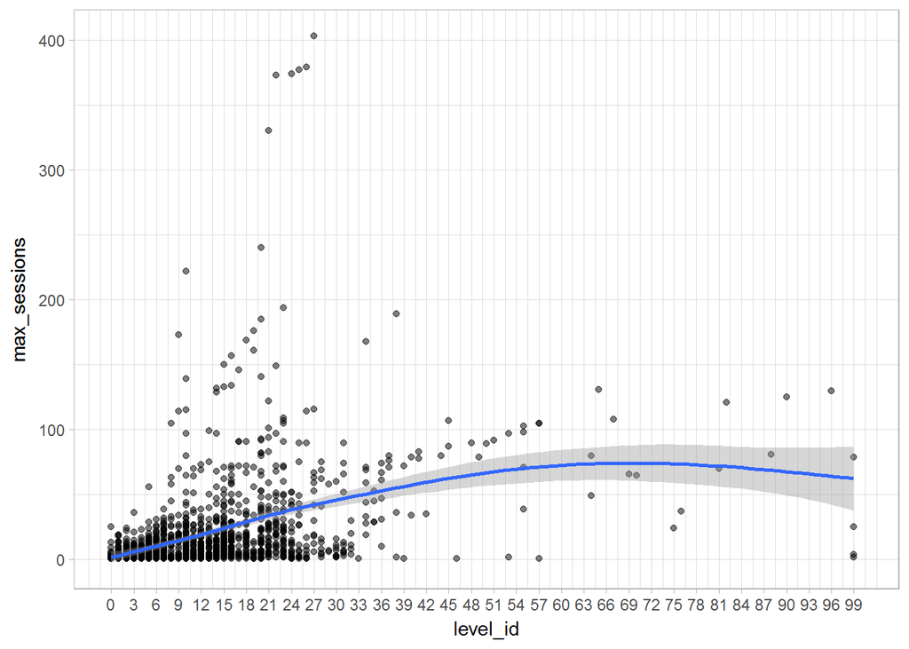

## **Question-3**

**What percentage of users make first time purchases between levels 1 to 7? (Refer to Spenders tab)**

purchase rate of users, who make first time purchases between levels 1 to 7 is

```
## [1] 53.21888
```

## **Question-4**

**What percentage of users make a repeat purchase? At what level maximum repeat purchases happen? (Refer to Spenders tab)**

**Here is the total percentage of users make a repeat purchase**

```
## [1] 63.9485
```

These are the levels at which maximum repeat purchases happened. These are the actual levels, at which maximum users repeated purchases rather than very few users.

```
## # A tibble: 50 x 2
##    level total
##    <int> <int>
##  1     1    50
##  2     2    48
##  3    10    42
##  4     3    32
##  5     6    32
##  6     9    28
##  7    12    26
##  8     0    24
##  9     5    24
## 10     7    22
## # ... with 40 more rows
```

## **Question-5**

**Which packs generate the maximum revenue? (Refer to Spenders tab)**

Total revenue is in terms of USD. I have taken care of currency convertion from one currency to other

```
## # A tibble: 29 x 2
##    pack_name         total
##    <fct>             <dbl>
##  1 Shop 5750 Tokens  25469
##  2 Shop 1006250 Orbs 11950
##  3 Shop 2800 Tokens   6330
##  4 Shop 490000 Orbs   3782
##  5 Shop 510 Tokens    1961
##  6 Shop 1100 Tokens   1804
##  7 Shop 100 Tokens    1463
##  8 Shop 192500 Orbs    820
##  9 Shop 250 Tokens     697
## 10 Shop 17500 Orbs     451
## # ... with 19 more rows
```